# Ch1-ML-landscape slides

[figure not shown]

### Instructor: Fereydoon "Fred" Vafaei

##### Session 2: Jan 30, 2020 - Chapter 1 - ML Landscpae

[figure not shown]

# Agenda

- **Quiz 0 - Syllabus**
- **Announcements - Assignment 0**
- **Introduction-handout feedback**
- **Chapter 1: ML Landscape**

# Announcements

```
- Schedule and reading assignments for Week 1 (Jan 27 - Jan 31): Chapter 1 - ML Landscpae
- Schedule and reading assignments for Week 2 (Feb 3 - Feb 7): Chapter 2 - End-to-end ML Projects
```

```
- Assignment 0: Jupyter Notebook & Piazza signup Due Thursday Feb 6th, 11:59PM
```

[figure not shown]

Image from: https://rapidminer.com/glossary/machine-learning/

# Definition of Machine Learning

- "Machine learning is the field of study that gives computers the ability to learn without being explicitly programmed." - Arthur Samuel
- "A computer program is said to learn from experience E with respect to some task T and some performance measure P, if its performance on T, as measured by P, improves with experience E." - Tom Mitchell

# Traditional Coding / Planning - Rule-based

[figure not shown]

# What Follows Next?

- 2, 4, 6, 8, 10, 12, ?
- 2, 4, 6, 8, 10, 12, **13**

# Why?

- 2, 4, 6, 8, 10, 12, 13, 2, 4, 6, 8, 10, 12, 13, 2, 4, 6, 8, 10, 12, 13, ...
- 2, 4, 6, 8, 10, 12, 13, 2, 4, 6, 8, 10, 12, 13, 2, 4, 6, 8, 10, 12, 13, 2, 4, 6, 8, 10, 12, ?
- 2, 4, 6, 8, 10, 12, 13, 2, 4, 6, 8, 10, 12, 13, 2, 4, 6, 8, 10, 12, 13, 2, 4, 6, 8, 10, 12, 9

# Learning Patterns

[figure not shown]

# Why ML?

- To address the challenge of maintenance of codes for complex problems - rule-based systems wouldn't work efficiently!
- To address the challenge of dynamic data or environments
- To address discovery or new knowlege in a domain
- To address Big Data

# Why ML?

[figure not shown]

# ML Can Help Humans Learn!

[figure not shown]

# ML Pipeline

[figure not shown]

https://blog.usejournal.com/machine-learning-for-beginners-from-zero-level-8be5b89bf77c

# ML Pipeline

[figure not shown]

AI Simplified: What is Machine Learning?

by Tom (DataRobot)

# Some Examples of ML Applications

# Image Classification, Object Detection, Object Recognition

[figure not shown]

```python
#Object Transfiguration

from IPython.display import YouTubeVideo
YouTubeVideo('9reHvktowLY', autoplay=1, width=800, height=500)
```

[video not shown]

# Natural Language Processing (NLP) and Decision Making Systems

[figure not shown]

# Machine Translation

[figure not shown]

# Playing Complex Games

- (19 x 19)! cases

[figure not shown]

# Self Driving Cars

[figure not shown]

# Recommender Systems

[figure not shown]

# Medical Image Analysis

[figure not shown]

# ML Approaches

- Supervised Learning
  - Classification
  - Regressions
- Unsupervised Learning
  - Clustering
  - Dimensionality Reduction
- Semi-supervised Learning
- Reinforcement Learning

# Supervised Learning

[figure not shown]

# Unsupervised Learning

[figure not shown]

# Unsupervised Learning - Clustering

[figure not shown]

# Semi-Supervised Learning

[figure not shown]

# Online Learning vs Batch Learning

[figure not shown]

# Online Learning for Huge Datasets - aka Incremental Learning

[figure not shown]

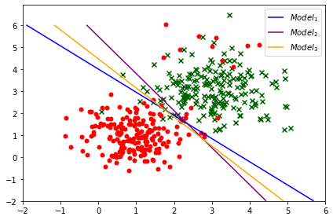

```python
# Example of a simple linear model

import warnings; warnings.simplefilter('ignore')
%matplotlib inline
%run -i 'python_scripts/simple_binary_classifier.py' --plot_model
```

# Nonlinear Patterns

[figure not shown]

# Supervised Learning: Regression vs Classification

Real-valued outputs vs finite set of categorical outputs

# Supervised Learning: Classification

- $f: \mathcal{X} \rightarrow y $
- Input: $\mathbf{x} \in {\rm I\!R}^d = \mathcal{X}$
- Output: $y \in \{-1, +1\}$
- Data: $D = \{ (\mathbf{x}_1, y_1), \dots, (\mathbf{x}_N, y_N) \}$ where $y_i = f(\mathcal{x}_i)$.

# Supervised Learning: Regression

- $f: \mathcal{X} \rightarrow y $
- Input: $\mathbf{x} \in {\rm I\!R}^d = \mathcal{X}$
- Output: $y \in {\rm I\!R}$
- Data: $D = \{ (\mathbf{x}_1, y_1), \dots, (\mathbf{x}_N, y_N) \}$ where $y_i = f(\mathcal{x}_i)$.

# Regression

[figure not shown]

<sub>Chris Bishop: Pattern Recognition</sub>

# Error in Regression

[figure not shown]

<sub>Chris Bishop: Pattern Recognition</sub>

# Polynomial Regression - Underfitting vs Overfitting

[figure not shown]

<sub>Chris Bishop: Pattern Recognition</sub>

# Main Challenges in ML

- **Insufficient Quantity of Data**
- **Non-representative Training Data**
- **Poor Quality Data**
- **Irrelevant Features**
- **Overfitting the training data**
- **Underfitting training data**

[figure not shown]

References:

- Hands-On ML Textbook
- Some slides are adopted from M.J. Lee's materials from UNCC